# MiniZinc Interface for R

Akshit Achara, Lars Kotthoff

2020-08-19

## Introduction

MiniZinc is a free and open-source constraint modeling language. Constraint satisfaction and discrete optimization problems can be formulated in a high-level modeling language. Models are compiled into an intermediate representation that is understood by a wide range of solvers. MiniZinc itself provides several solvers, for instance GeCode. The existing packages in R are not powerful enough to solve even mid-sized problems in combinatorial optimization

There are implementations of an Interface to MiniZinc in Python like MiniZinc Python and pymzn and JMiniZinc for Java but such an interface does not exist for R.

This package provides an implementation of a very simple and easy to use interface for R that will help R users to solve optimization problems that can’t be solved with R currently.

It’s important to understand R6 classes before getting into the details. If you are not comfortable with R6, please go through this [tutorial](https://adv-r.hadley.nz/r6.html).

It would be nice to go through this [manual](https://www.minizinc.org/tutorial/minizinc-tute.pdf) to understand more about MiniZinc. This is mainly for those who are interested in contributing to the package.

Please make sure to install MiniZinc on your operating system and also ensure that minizinc is accessible from command line by typing ‘minizinc’ on the command line without the single quotes. The installation instructions can be found at [instructions](https://www.minizinc.org/doc-2.4.3/en/installation.html)

## Variables

There are two types of variables in MiniZinc namely, decision variables and parameters.

The data types of variables can be single types i.e integers (int), floating point numbers (float), Booleans (bool) and strings (string) and collections i.e sets, enums and arrays (upto 6 dimensional arrays).

Parameter is used to specify a parameter in a given problem and they are assigned a fixed value or expression.

Decision variables are the unknowns that Minizinc model is finding solutions for. We do not need to give them a value, but instead we give them a domain of possible values. Sometimes expressions involving other variables and parameters are also assigned to decision variables. Decision variables need to satisfy a set of constraints which form the core of the problem.

To create a variable declaration one needs to understand the elements of R6 classes that will be used to create the variables.

The type information of the declaration is stored in an object of class Type which holds information like base type, number of dimensions, etc. The type inst is stored in an object of TypeInst class which contains the type information as well as the index or domain in case the variable is an array or decision variable with domain respectively. The value assigned to the variable declaration is stored in an object of sub classes of super class Expression that can be Int, Float, Array, or other Expression sub classes that result in a value of corresponding type.

Easy to use declaration functions have been created for the users to declare variables and parameters of different data types. Examples of how to declare variables is shown below.

Let’s create parameters and decision variables.

```r
library(rminizinc)

# create the variable and parameter declarations
item1 = VarDeclItem$new(decl = IntDecl(name = "n", kind = "par"))

par2_val = BinOp$new(lhs = Int$new(1), binop = "..", rhs = item1$id())
item2 = VarDeclItem$new(decl = IntSetDecl(name = "OBJ", kind = "par", value = par2_val))

item3 = VarDeclItem$new(decl = IntDecl(name = "capacity", kind = "par"))

item4 = VarDeclItem$new(decl = IntArrDecl(name = "profit", kind = "par", ndim = 1,
                                          ind = list(item2$id())))

item5 = VarDeclItem$new(decl = IntArrDecl(name = "size", kind = "par", ndim = 1, ind =                                                            list(item2$id())))

item6 = VarDeclItem$new(decl = IntArrDecl(name = "x", kind = "var", ndim = 1, ind = list(item2$id())))
```

## Constraints

Constraints are defined on the decision variables to restrict the range of values that they can take. They can also be thought of as the rules of a problem.

Constraints can be created using different R6 sub classes of the super class Expression. In this example Generator, Binop, Comprehension and Call classes have been used. These classes take in the elements required to create an expression that will be used as a constraint. More information can be found using `?<class Name>`

Create constraints:

```r
# declare parameter for iterator
parIter = IntDecl(name = "i", kind = "par")


gen_forall = Generator$new(IN = item2$id(), decls = list(parIter))
bop1 = BinOp$new(lhs = ArrayAccess$new(v = item6$id(),  args= list(gen_forall$decl(1))),
                                                             binop = ">=", rhs = Int$new(0))

Comp1 = Comprehension$new(generators = list(gen_forall), body = bop1, set = FALSE)
cl1 = Call$new(fnName = "forall", args = list(Comp1))
item7 = ConstraintItem$new(e = cl1)

gen_sum = Generator$new(IN = item2$id(), decls = list(parIter))

bop2 = BinOp$new(lhs = ArrayAccess$new(v = item5$id(), args = list(gen_sum$decl(1))),
                 binop = "*",  rhs = ArrayAccess$new(v = item6$id() ,
                 args = list(gen_sum$decl(1))))

Comp2 = Comprehension$new(generators = list(gen_sum), body = bop2, set = FALSE)
cl2 = Call$new(fnName = "sum", args = list(Comp2))
bop3 = BinOp$new(lhs = cl2, binop = "<=", rhs = item3$id())
item8 = ConstraintItem$new(e = bop3)
```

## Solve Type

The constraint programming problem can be of three types, namely: Satisfaction , Minimization and Maximization. Satisfaction problems produce all the solutions that satisfy the constraints whereas minimization and maximization problems produce the solution which minimizes and maximizes the given arithmetic expression.

An example is shown below:

```r
bop4 = BinOp$new(lhs = ArrayAccess$new(v = item4$id(), args = list(gen_sum$decl(1))),
                      binop = "*", rhs = ArrayAccess$new(v = item6$id(),
                      args = list(gen_sum$decl(1))))

Comp3 = Comprehension$new(generators = list(gen_sum), body = bop4, set = FALSE)

cl3 = Call$new(fnName = "sum", args = list(Comp3))

item9 = SolveItem$new(solve_type = "maximize", e = cl3)
```

## Create the model

The model is created by combining these items.

Combine all the items to create a MiniZinc model

```r
items  = c(item1, item2, item3, item4, item5, item6, item7, item8, item9)
mod = Model$new(items = items)
modString = mod$mzn_string()
cat(modString)
```

```
## int: n;
##
## set of int: OBJ = (1 .. n);
##
## int: capacity;
##
## array[OBJ] of int: profit;
##
## array[OBJ] of int: size;
##
## array[OBJ] of var int: x;
##
## constraint forall([(x[i] >= 0) | i in OBJ ]);
##
## constraint (sum([(size[i] * x[i]) | i in OBJ ]) <= capacity);
##
## solve  maximize sum([(profit[i] * x[i]) | i in OBJ ]);
```

## Solve the model

Solve the model using the Rcpp functions that are using the MiniZinc.

```r
dzn_path = paste0(dirname(getwd()), "/inst/extdata/mzn_examples/knapsack/knapsack_0.dzn")
sol = rminizinc:::mzn_eval(modelString = modString, solver = "org.gecode.gecode",
                      libpath = "/snap/minizinc/current/share/minizinc", dznpath = dzn_path)
print(sol$SOLUTIONS$OPTIMAL_SOLUTION)
```

```
## $x
## [1] 1 1 1
```

## Delete Items

All the item classes have a `delete()` function which is used to delete the item. An example to demonstrate the same is shown below:

```r
# delete the item 1
item1$delete()
```

```
## VarDeclItem object deleted!
```

```r
# check that item1 has been deleted
ls(pattern = "item[^a-z]")
```

```
## [1] "item2" "item3" "item4" "item5" "item6" "item7" "item8" "item9"
```

```r
# item1 reference is deleted but items vector should be updated
items = c(item2, item3, item4, item5, item6, item7, item8, item9)
mod = Model$new(items)
cat(mod$mzn_string())
```

```
## set of int: OBJ = (1 .. n);
##
## int: capacity;
##
## array[OBJ] of int: profit;
##
## array[OBJ] of int: size;
##
## array[OBJ] of var int: x;
##
## constraint forall([(x[i] >= 0) | i in OBJ ]);
##
## constraint (sum([(size[i] * x[i]) | i in OBJ ]) <= capacity);
##
## solve  maximize sum([(profit[i] * x[i]) | i in OBJ ]);
```

Now, that the basic structure of the problem is clear, we can create functions for solving different constraint programming problems.

The workflow of the approach used above is given below:

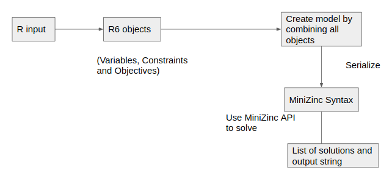

This approach is helpful for R users who have little understanding of MiniZinc.

The next approach is to use the MiniZinc C++ API. This involves giving the MiniZinc model to the Rcpp function, evaluate the results and return them back to R. The workflow can be seen below:

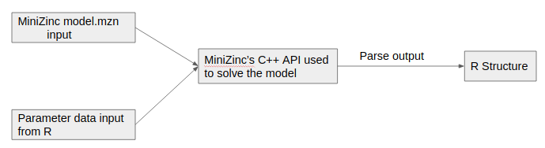

## Parse Model, Set Missing Parameters and Solve

### Parse a MiniZinc model

A parser function `mzn_parse` has also been implemented which can be used to detect possible syntax errors and get the smallest of details before the MiniZinc model is evaluated. This function can either take the path of a model file path or it can take a string model and returns a list with different elements like: `MODEL_STRING` which is the string representation of the model and `VARIABLES` which are the variable declaration details, `CONSTRAINTS` which are the constraint details of a model, `SOLVE_TYPE` which contains the information about the solve type of the problem, `FUNCTION_ITEMS` contains the function information, `ASSIGNMENTS` contains the assignment information, `INCLUDES` contains information about the included mzn files and `OUTPUT_ITEM` contains the information about the output formatting. Each component (Variable Declarations, Constraints, Solve Items, Assignment Items, Include Items, Functions and Assignments) in a MiniZinc model is considered as an item. The `ITEM_NO` for each element is also returned. If your model includes an mzn file, you can provide custom paths of the folders where the included files are present. The default mzn files (in the std folder) provided along with libminizinc will be included by default.

The Information about the naming of the elements returned is described in the following figures:

### Model Items

*Name*: `VARIABLES`  
*Components*: `DECL<n>` is the list of declaration with components `DETAILS` and `ITEM_NO`  
*Description*: `DETAILS` are the details of a variable declaration namely: `NAME`, `TYPE_INST` and `VALUE` and `ITEM_NO` is the item number of the variable declaration in the model.

*Name*: `CONSTRAINTS`  
*Components*: `CONSTRAINT<n>` is the list of constraints with components: `DETAILS` and `ITEM_NO`.  
*Description*: `DETAILS` are the details about the expressions.

*Name*: `FUNCTION_ITEMS`  
*Components*: `FUNCTION<n>` is the list of functions with components: `DETAILS` and `ITEM_NO`.  
*Description*: `DETAILS` are the details that can `EXPRESSION`, `ANNOTATION`, `TYPE_INST` `PARAMETER_DECLARATIONS`.

*Name*: `SOLVE_TYPE`  
*Components*: `DETAILS`, `OBJECTIVE` and `ITEM_NO`  
*Description*: `DETAILS` are the details that can `EXPRESSION` or `ANNOTATION`, `OBJECTIVE` can be “satisfy”, “minimize” or “maximize”.

*Name*: `ASSIGNMENTS`  
*Components*: `ASSIGNMENT<n>` have the sub components: `DETAILS` and `ITEM_NO`.  
*Description*: `DETAILS` contain the value expression details.

*Name*: `INCLUDES`  
*Components*: `INCLUDED_MZN` and `ITEM_NO` *Description*: `INCLUDED_MZN` is the name of the included mzn file.

*Name*: `OUTPUT_ITEM`  
*Components*: `DETAILS` and `ITEM_NO`.  
*Description*: `DETAILS` are the details about the output formatting expression.

### Basic Expressions

These are the expressions that lie at the lowest level when parsing any expression.

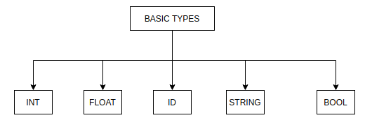

### Parent_Expressions

These are the expressions that are above the basic types in hierarchy and can have sub expressions that can be either basic expressions or parent expressions.

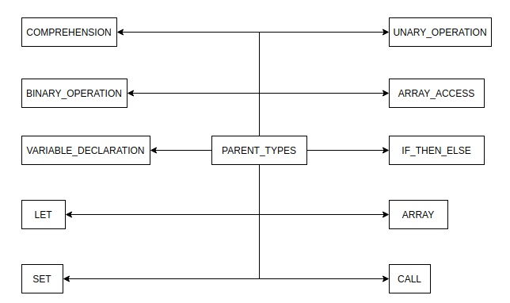

#### Properties of Parent Expressions

Each parent has different properties that define it’s structure. The properties of each of the parent are described below:

*Name*: `COMPREHENSION`  
*Components*: `GENERATORS` and `EXPRESSION`  
*Description*: `GENERATORS` is a list of expressions and each generator contains `DECLARATIONS` (list of variable declarations), `IN_EXPRESSION` and `WHERE_EXPRESSION` (Expressions). and `EXPRESSION` is the expression in the comprehension.

*Name*: `BINARY_OPERATION`  
*Components*: `LHS`, `BINARY_OPERATOR` and `RHS`  
*Description*: `LHS` and `RHS` are both expressions (basic or parent) and `BINARY_OPERATOR` is a binary operator in MiniZinc.

*Name*: `UNARY_OPERATION`  
*Components*: `UNARY_OPERATOR` and `ARGUMENTS`  
*Description*: `UNARY_OPERATOR` are the unary operators in MiniZinc and `ARGUMENTS` contain a list of expressions.

*Name*: `VARIABLE_DECLARATION`  
*Components*: `NAME`, `TYPE_INST` (`KIND`, `TYPE`, `DOMAIN`, `INDEX`) and `VALUE`  
*Description*: `NAME`, `KIND` and `TYPE` are strings representing the name, kind and type of the variable and `DOMAIN` and `VALUE` are expressions representing domain and value of the variable declaration. `TYPE_INST` contains the `KIND`, `TYPE`, `DOMAIN` and `INDEX`.

*Name*: `ARRAY_ACCESS`  
*Components*: `NAME` and `ARGUMENTS`  
*Description*: `NAME` is the name of the variable and `ARGUMENTS` is the list of expressions that represent the indices.

*Name*: `IF_THEN_ELSE`  
*Components*: `IF`, `THEN` and `ELSE`  
*Description*: `IF` is the list of if expressions, `THEN` is the list of then expressions and `ELSE` is the else expression.

*Name*: `LET`  
*Components*: `LET_EXPRESSION` and `IN_EXPRESSION`  
*Description*: `LET_EXPRESSION` and `IN_EXPRESSION` are lists of expressions.

*Name*: `CALL`  
*Components*: `NAME` and `ARGUMENTS`  
*Description*: `NAME` is the name of the function call and `ARGUMENTS` is the list of expressions to that function call.

*Name*: `SET`  
*Components*: `MIN`, `MAX` (set ranges) or `ELEMENT<n>` where n is the serial number of the element.  
*Description*: `MIN` , `MAX` and `ELEMENT<n>` are all expression types (mostly basic expressions).

*Name*: `ARRAY`  
*Components*: `ELEMENT<n>` where n is the serial number of the element.  
*Description*: `ELEMENT<n>` is an expression.

Now, let’s parse a job shop model:

```r
# mzn file path
mzn_path = paste0(dirname(getwd()), "/inst/extdata/mzn_examples/jobshop/jobshop_0.mzn")

# parse the model
parseObj=rminizinc:::mzn_parse(mznpath = mzn_path)
```

```
## Using default include path: /usr/local/lib/libminizinc/share/minizinc/std
```

Look at the contents of parseObj for more understanding of the model.

### Find the Missing Parameters

The missing parameters can be obtained using `get_missing_pars()`

```r
missingPars = get_missing_pars(modelString = parseObj$MODEL_STRING)
```

```
## Using default include path: /usr/local/lib/libminizinc/share/minizinc/std
```

```r
print(missingPars)
```

```
## [1] "n"  "m"  "d"  "mc"
```

### Set Values of Missing Parameters

```r
pVals = list(3, 4, c(3, 3, 4, 4, 4, 3, 2, 2, 3, 3, 3, 4),
             c(1, 2, 3, 4, 1, 3, 2, 4, 4, 2, 1, 3))
names(pVals) = missingPars
modString = set_params(modData = pVals, mznpath = mzn_path)
```

```
## Using default include path: /usr/local/lib/libminizinc/share/minizinc/std
```

### Solve the Model

The function `mzn_eval()` is used to evaluate a MiniZinc model and returns the solution string and a list of solutions if they were parsed without any error by the function `sol_parse()` otherwise it returns the solution string and an appropriate error. The parsed solutions are a named list where elements are of type `OBJ$SOLUTIONS$SOLUTION<n>$<VARIABLE_NAME>`. The optimal solution if found can be accessed using `OBJ$SOLUTIONS$OPTIMAL_SOLUTION` and the best solution can be accessed using `OBJ$SOLUTIONS$BEST_SOLUTION`. More details about the functions can be obtained using `?mzn_eval` and `?sol_parse`.

The solver that should be used to solve the model needs to be specified by the user (default is Gecode) and the libpath (path of the MiniZinc executable) should also be provided. If the user wishes to provide a data file, it’s path can be provided to the argument `dznpath`. A time limit (in ms) can also be provided to the argument `time_limit`. (default is 300000 ms)

A sample job shop problem has been solved below:

```r
# R List object containing the solutions
solObj = rminizinc:::mzn_eval(modelString = modString, solver = "org.gecode.gecode",
                     libpath = "/snap/minizinc/current/share/minizinc")
# get all the solutions
print(solObj$SOLUTIONS)
```

```
## $OPTIMAL_SOLUTION
## $OPTIMAL_SOLUTION$s
## $OPTIMAL_SOLUTION$s[[1]]
## [1]  0  3  6 10
##
## $OPTIMAL_SOLUTION$s[[2]]
## [1]  3 10 13 15
##
## $OPTIMAL_SOLUTION$s[[3]]
## [1]  0  6  9 13
```

Let’s solve another problem.

```r
# file path
mzn_path = paste0(dirname(getwd()), "/inst/extdata/mzn_examples/knapsack/knapsack_0.mzn")

# get missing parameter values
missingVals=rminizinc:::get_missing_pars( mznpath = mzn_path)
```

```
## Using default include path: /usr/local/lib/libminizinc/share/minizinc/std
```

```r
print(missingVals)
```

```
## [1] "n"        "capacity" "profit"   "size"
```

```r
# list of the data
pVals = list(3, 9, c(15,10,7), c(4,3,2))
names(pVals) = missingVals

# set the missing parameters
modString = rminizinc:::set_params(modData = pVals,mznpath = mzn_path, modify_mzn = FALSE)
```

```
## Using default include path: /usr/local/lib/libminizinc/share/minizinc/std
```

```r
# R List object containing the solutions
solObj = rminizinc:::mzn_eval(modelString = modString, solver = "org.gecode.gecode",
                     libpath = "/snap/minizinc/current/share/minizinc")
# get all the solutions
print(solObj$SOLUTIONS)
```

```
## $SOLUTION0
## $SOLUTION0$x
## [1] 0 0 0
##
##
## $SOLUTION1
## $SOLUTION1$x
## [1] 0 0 1
##
##
## $SOLUTION2
## $SOLUTION2$x
## [1] 0 0 2
##
##
## $SOLUTION3
## $SOLUTION3$x
## [1] 0 0 3
##
##
## $SOLUTION4
## $SOLUTION4$x
## [1] 0 0 4
##
##
## $SOLUTION5
## $SOLUTION5$x
## [1] 0 1 3
##
##
## $OPTIMAL_SOLUTION
## $OPTIMAL_SOLUTION$x
## [1] 1 1 1
```

Some examples of how to use these functions to solve optimization problems can be found in `mzn_examples` which are taken from minizinc-examples.

NOTE: Please don’t include output formatting in the mzn files or the solutions might not be parsed properly.

The named list returned by `mzn_parse()` can be used to initialize all the R6 classes in the MiniZinc API mirror required to create the model that was parsed. This will help the user to use a lot of functions to understand, manipulate and use the model using the R6 objects. `getRModel()` is used to initialize all the relevant objects using named list returned by `mzn_parse()`.

```r
# mzn file path
mzn_path = paste0(dirname(getwd()), "/inst/extdata/mzn_examples/production_planning/prod_plan_0.mzn")

# parse the model
parseObj = rminizinc:::mzn_parse(mznpath = mzn_path)
```

```
## Using default include path: /usr/local/lib/libminizinc/share/minizinc/std
```

```r
modString = getRModel(parseObj)$mzn_string()

# dzn file path
dzn_path = paste0(dirname(getwd()), "/inst/extdata/mzn_examples/production_planning/prod_plan_0.dzn")

# R List object containing the solutions
solObj = rminizinc:::mzn_eval(modelString = modString, solver = "org.gecode.gecode",
                     libpath = "/snap/minizinc/current/share/minizinc", dznpath = dzn_path)
# get all the solutions
print(solObj$SOLUTIONS)
```

```
## $SOLUTION0
## $SOLUTION0$produce
## [1] 0 0
##
## $SOLUTION0$used
## [1] 0 0 0 0 0
##
##
## $SOLUTION1
## $SOLUTION1$produce
## [1] 1 0
##
## $SOLUTION1$used
## [1] 250   2  75 100   0
##
##
## $SOLUTION2
## $SOLUTION2$produce
## [1] 2 0
##
## $SOLUTION2$used
## [1] 500   4 150 200   0
##
##
## $SOLUTION3
## $SOLUTION3$produce
## [1] 3 0
##
## $SOLUTION3$used
## [1] 750   6 225 300   0
##
##
## $SOLUTION4
## $SOLUTION4$produce
## [1] 2 1
##
## $SOLUTION4$used
## [1] 700   4 300 350  75
##
##
## $SOLUTION5
## $SOLUTION5$produce
## [1] 3 1
##
## $SOLUTION5$used
## [1] 950   6 375 450  75
##
##
## $OPTIMAL_SOLUTION
## $OPTIMAL_SOLUTION$produce
## [1] 2 2
##
## $OPTIMAL_SOLUTION$used
## [1] 900   4 450 500 150
```

The next step is to allow the users to modify a MiniZinc model using the R6 objects which will be demonstrated soon.